# Final Project Data Science for Political Science

Gavin Lam

2024-12-18

```r
Finaldata <- read.csv("31116083.csv")
```

```r
table(Finaldata$PWMGNIMP1)
```

```
##
##               Less crime               More crime Or not make a difference
##                      232                      231                      379
##                  Refused                   Unsure
##                        1                       37
```

```r
BGCHECKS <- Finaldata$GLWBKGDCK1
Finaldata$binarybgchecks <- NA
Finaldata$binarybgchecks[Finaldata$GLWBKGDCK1 == "Make a difference"] <- 1
Finaldata$binarybgchecks[Finaldata$GLWBKGDCK1 == "Not make a difference"] <- 0
Finaldata <- Finaldata[!is.na(Finaldata$binarybgchecks), ]
table(Finaldata$GENDER)
```

```
##
##   Men Women
##   286   258
```

```r
Finaldata$binarygender <- NA
Finaldata$binarygender[Finaldata$GENDER == "Men"] <- 1
Finaldata$binarygender[Finaldata$GENDER == "Women"] <- 0
```

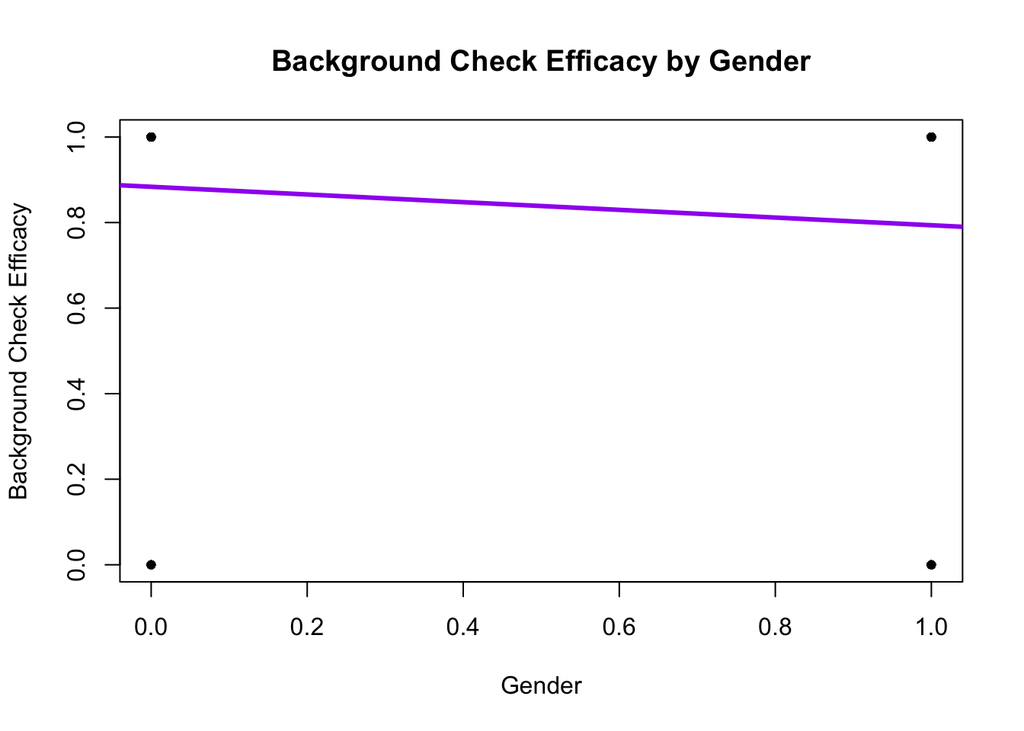

```r
fit <- lm(binarybgchecks ~ binarygender, data = Finaldata)
plot(x = Finaldata$binarygender, y = Finaldata$binarybgchecks,
     ylab = "Background Check Efficacy",
     xlab = "Gender",
     main = "Background Check Efficacy by Gender",
     pch = 20)
abline(fit, lwd=3, col = "purple")
```

Because the data was translated into binary 0’s and 1’s, with 1 representing male and a belief that background checks work and 0 representing female and a belief that background checks do not work, there is only four points on the scatterplot. However, the plot still shows that 88% of women believe that background checks are effective while 79% of men feel the same way.

```r
t_test_result <- t.test(binarybgchecks ~ binarygender, data = Finaldata)
print(t_test_result)
```

```
##
##  Welch Two Sample t-test
##
## data:  binarybgchecks by binarygender
## t = 2.8837, df = 533.29, p-value = 0.004089
## alternative hypothesis: true difference in means between group 0 and group 1 is not equal to 0
## 95 percent confidence interval:
##  0.02869596 0.15133331
## sample estimates:
## mean in group 0 mean in group 1
##       0.8837209       0.7937063
```

To determine if these results are significant, I performed a hypothesis test. The null hypothesis is that there is no difference between men and women in the mean belief that background checks work. The alternative hypothesis is that there is a difference between men and women in the mean belief that background checks work. Using a confidence interval of 95%, I am 95% confident that the true mean difference between men and women in the belief that background checks work lies between 0.03 and 0.15. Additionally, because the p-value < 0.05 I reject the null hypothesis that there is no difference between men and women in the mean belief that background checks work.